# Fairness Report

First Author

## Audit Report: Summary

This document introduces on how to use `mlr3fairness` to create audit reports with different tasks throughout the fairness exploration process.

There are three main sections for this document. Which describe the details for the task, the model and the interpretability of the parameters.

Jump to section:

- Task details
- Model details
- Interpretability

## Task details

In this fairness report, we investigate the fairness of the following task:

```
#>
#> ── <TaskClassif> (700x5) ───────────────────────────────────────────────────────
#> • Target: target
#> • Target classes: <=50K (positive class, 77%), >50K (23%)
#> • Properties: twoclass
#> • Features (4):
#> • Protected attribute: sex
```

### Task Documentation:

Here we the basic details for the task.

[output not shown]

### Exploratory Data Analysis:

We also report the number of missing values, types and the levels for each feature:

|  | id | type | levels | label | fix_factor_levels | Missings…. |
| --- | --- | --- | --- | --- | --- | --- |
| 5 | education | factor | 10th , 11th , 12th , 1st-4th , 5th-6th , 7th-8th , 9th , Assoc-acdm , Assoc-voc , Bachelors , Doctorate , HS-grad , Masters , Preschool , Prof-school , Some-college | NA | FALSE | 0 |
| 8 | marital_status | factor | Divorced , Married-AF-spouse , Married-civ-spouse , Married-spouse-absent, Never-married , Separated , Widowed | NA | FALSE | 0 |
| 10 | race | factor | Amer-Indian-Eskimo, Asian-Pac-Islander, Black , Other , White | NA | FALSE | 0 |
| 12 | sex | factor | Female, Male | NA | FALSE | 0 |
| 13 | target | factor | <=50K, >50K | NA | FALSE | 0 |

We first look at the label distribution:

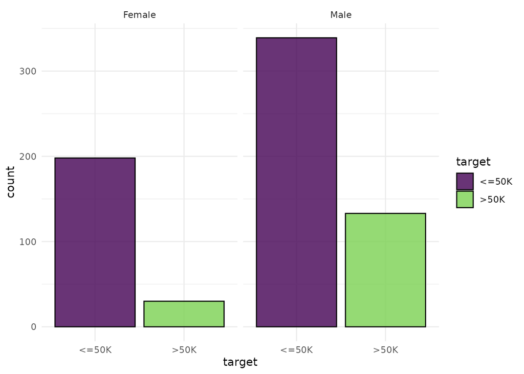

## Model details

We could see the model that has been used in `resample_result`:

```
#>
#> ── <LearnerClassifRpart> (classif.rpart): Classification Tree ──────────────────
#> • Model: -
#> • Parameters: xval=0
#> • Packages: mlr3 and rpart
#> • Predict Types: response and [prob]
#> • Feature Types: logical, integer, numeric, factor, and ordered
#> • Encapsulation: none (fallback: -)
#> • Properties: importance, missings, multiclass, selected_features, twoclass,
#> and weights
#> • Other settings: use_weights = 'use', predict_raw = 'FALSE'
```

### Fairness Metrics

We furthermore report more than one fairness metric. Below metrics are the mean across all the resample results.

|  | value |
| --- | --- |
| fairness.acc | 0.0850618 |
| fairness.equalized_odds | 0.1629949 |
| fairness.fnr | 0.0972116 |
| fairness.fpr | 0.2287782 |
| fairness.ppv | 0.0883333 |
| fairness.pp | 0.1692584 |

We can furthermore employ several visualizations to report the fairness. For example, the fairness and accuracy trade off, compare metrics visualization and the fairness prediction density of our model. For more detailed usage and examples, you may want to check the [visualization vignette](https://mlr3fairness.mlr-org.com/articles/visualization-vignette.html).

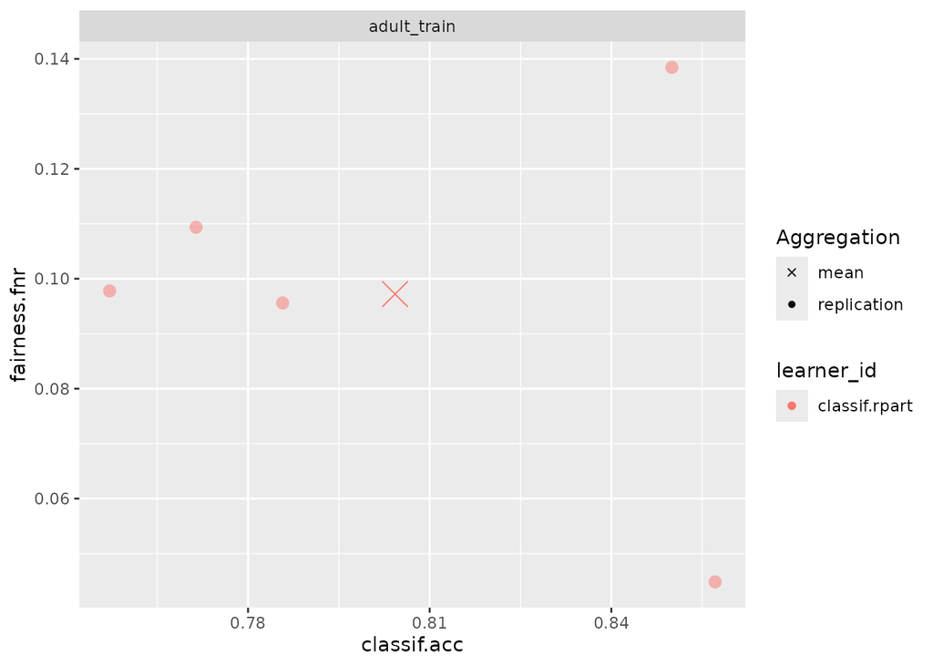

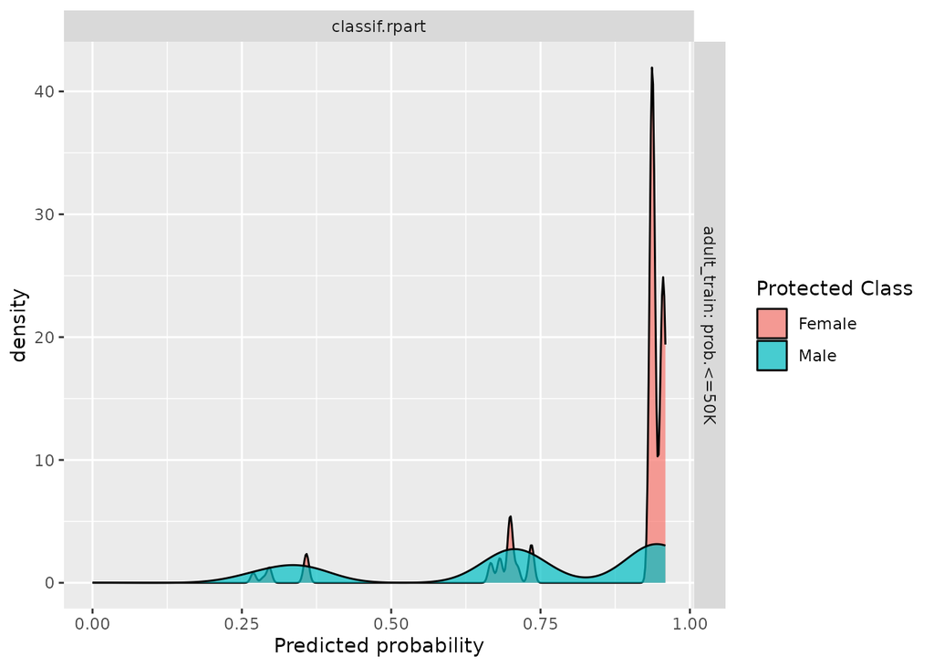

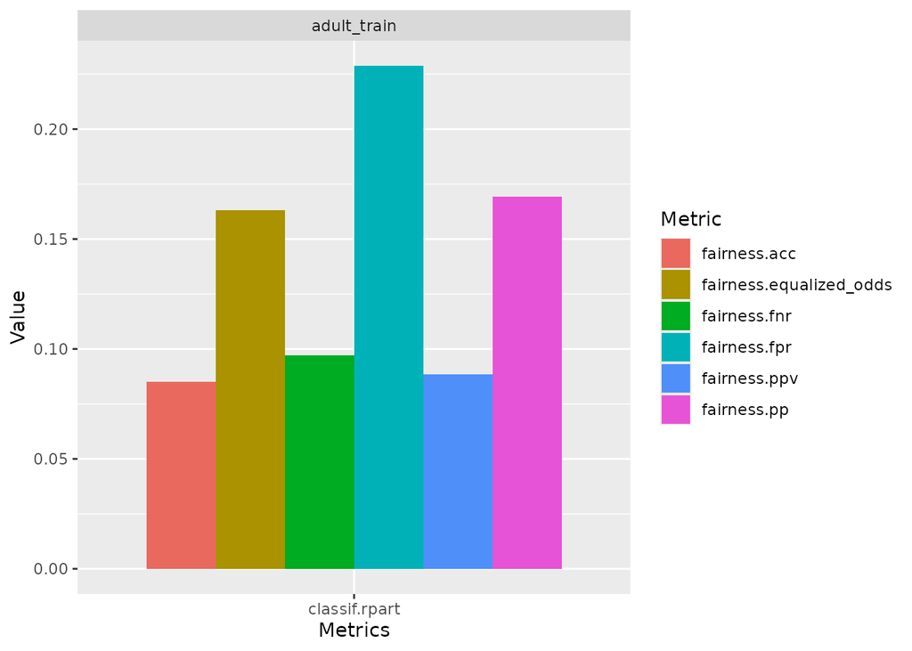

## Interpretability

Finally, we use the external package to gain further insight into our model. For the following example we use the `iml` package as a demonstration. We need first extract the learner from `resample_result` and wrap it in a `Predictor` object.

You could generate the variable importance plot like this

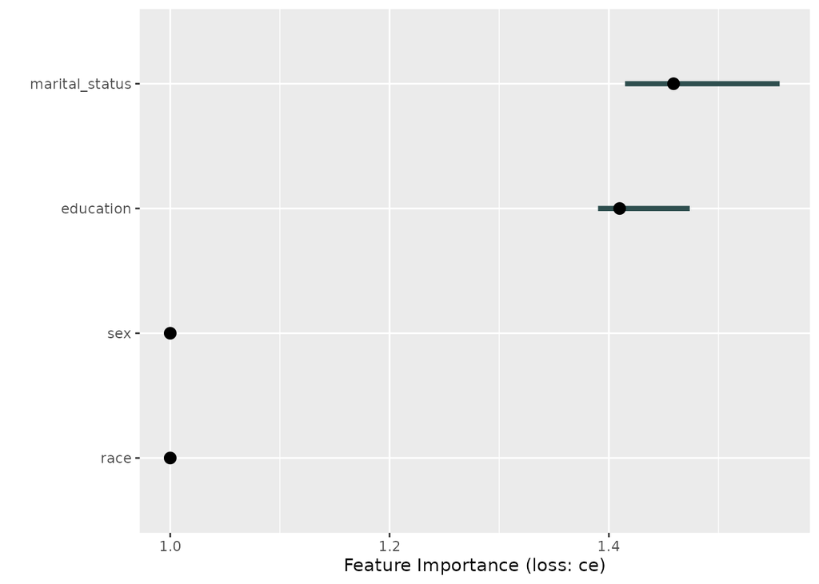

Or generate the feature effects plot:

[figure not shown]

For more details on interpretability, check the documentation of the `iml` package.